# Titanic_Final_V1.1

## TITANIC - Análise de dados

### INTRODUÇÃO:

O RMS Titanic foi um navio de passageiros britânico que começou a ser construido em 1909. Foi construido para ser o navio mais pesado e mais luxuoso nafio da época, gerando lendas de que era supostamente "infundável".

Sua viagem inaugural foi em 10 de Abril de 1912 e partiu de Southampton (Reino Unido) com destino a Nova York (Estados Unidos), passando por Cherbourg-Octeville (França) e Queenstown na Irlanda. Em 14 de Abril às 23:40 ele colidiu com um iceberg e afundou na madrugada do dia seguinte com mais de 1.500 pessoas a bordo, sendo considerado um dos maiores naufrágios da história. Menos de um terço daqueles que estavam a bordo do Titanic sobreviveram. Os motivos para o naufrágio foram diversas causas, tanto naturais quanto humanas. Este acontecimento expôs diversas fragilidades levando a mudanças nas leis internacionais de nevegação.

### Seguem algumas perguntas a serem investigadas:

- Os passageiros das primeiras classes tiveram maiores chances de sobrevivência?
- As mulheres tiveram maior chance de sobrevivência que os homens?
- As mulheres da primeira classe tiveram maior chance de sobrevivência que as mulheres da terceira classe?
- Crianças tiveram uma taxa maior de sobrevivência?
- Crianças da primeira e segunda classe sobreviveram mais que as crianças da terceria classe?
- Importando as bibliotecas e configurando parâmetros gerais:

```python
import numpy as np
import pandas as pd
import matplotlib.pyplot as plt
import seaborn as sns
import warnings

warnings.filterwarnings('ignore')

pd.options.display.float_format = '{:.2f}'.format

%matplotlib inline
plt.style.use('fivethirtyeight')
plt.rcParams['figure.figsize'] = (15,5)

vcolor  = ['tab:blue', 'tab:red', 'tab:green', 'tab:orange', 'tab:purple', 'tab:brown', 'tab:gray', 'tab:pink', 'tab:olive', 'tab:cyan']
vcolor2 = ['tab:green', 'tab:blue', 'tab:red', 'tab:orange', 'tab:purple', 'tab:brown', 'tab:gray', 'tab:pink', 'tab:olive', 'tab:cyan']
```

- Carregando o dataset (disponibilizado pela Udacity):

```python
df = pd.read_csv('titanic_data.csv')
```

### DICIONÁRIO DE DADOS:

###### VARIÁVEIS

Survived (Sobreviveu): 0 = Não, 1 = Sim  
Pclass (Classe): Classe de ingresso 1 = 1º, 2 = 2º, 3 = 3º  
Sex (Sexo): Sexo do passageiro  
Age (Idade): Idade em anos  
Sibsp: Quantidade de irmãos / cônjuges a bordo do Titanic  
Parch: Quantidade de pais / crianças a bordo do Titanic  
Ticket (Bilhete): Número do bilhete de embarque  
Fare (Tarifa): Tarifa paga pelo Passageiro  
Cabin (Cabine): Número de cabine  
Embarked (Embarque): Porto de Embarque (C = Cherbourg, Q = Queenstown, S = Southampton)

###### Notas sobre as variáveis

**Pclass** (Classe): 1º = Superior 2º = Médio 3º = inferior

**Age** (Idade): A idade é fracionada se for inferior a 1. Se a idade for estimada, é na forma de xx.5

**Sibsp**: O conjunto de dados define as relações familiares dessa maneira ...  
Sibling = Irmão, irmã, meio-irmão, irmandade  
Spouse (Cônjuge) = marido, esposa (amantes e desposados foram ignorados)

**Parch**: O conjunto de dados define as relações familiares dessa maneira ...  
Parent (Pais) = mãe, pai  
Child (Criança) = filha, filho, enteada, enteado  
Algumas crianças viajaram apenas com uma babá, portanto, parch = 0 para elas.

### CONHECENDO O DATASET

Analisando as dimensões do dataset

```python
print('N. linhas:', df.shape[0])
print('N. colunas:', df.shape[1])
```

```
N. linhas: 891
N. colunas: 12
```

Significa que esta base de dados não contém as informações de todas as pessoas abordo do Titanic. Contém informações apenas de 891 pessoas.

Visualização dos primeiros e dos ultimos 5 registros:

```python
df.head()
```

|  | PassengerId | Survived | Pclass | Name | Sex | Age | SibSp | Parch | Ticket | Fare | Cabin | Embarked |
| --- | --- | --- | --- | --- | --- | --- | --- | --- | --- | --- | --- | --- |
| 0 | 1 | 0 | 3 | Braund, Mr. Owen Harris | male | 22.00 | 1 | 0 | A/5 21171 | 7.25 | NaN | S |
| 1 | 2 | 1 | 1 | Cumings, Mrs. John Bradley (Florence Briggs Th... | female | 38.00 | 1 | 0 | PC 17599 | 71.28 | C85 | C |
| 2 | 3 | 1 | 3 | Heikkinen, Miss. Laina | female | 26.00 | 0 | 0 | STON/O2. 3101282 | 7.92 | NaN | S |
| 3 | 4 | 1 | 1 | Futrelle, Mrs. Jacques Heath (Lily May Peel) | female | 35.00 | 1 | 0 | 113803 | 53.10 | C123 | S |
| 4 | 5 | 0 | 3 | Allen, Mr. William Henry | male | 35.00 | 0 | 0 | 373450 | 8.05 | NaN | S |

```python
df.tail()
```

|  | PassengerId | Survived | Pclass | Name | Sex | Age | SibSp | Parch | Ticket | Fare | Cabin | Embarked |
| --- | --- | --- | --- | --- | --- | --- | --- | --- | --- | --- | --- | --- |
| 886 | 887 | 0 | 2 | Montvila, Rev. Juozas | male | 27.00 | 0 | 0 | 211536 | 13.00 | NaN | S |
| 887 | 888 | 1 | 1 | Graham, Miss. Margaret Edith | female | 19.00 | 0 | 0 | 112053 | 30.00 | B42 | S |
| 888 | 889 | 0 | 3 | Johnston, Miss. Catherine Helen "Carrie" | female | nan | 1 | 2 | W./C. 6607 | 23.45 | NaN | S |
| 889 | 890 | 1 | 1 | Behr, Mr. Karl Howell | male | 26.00 | 0 | 0 | 111369 | 30.00 | C148 | C |
| 890 | 891 | 0 | 3 | Dooley, Mr. Patrick | male | 32.00 | 0 | 0 | 370376 | 7.75 | NaN | Q |

Note acima que a coluna Age contém uma informação preenchida com o valor NaN, significa que o campo esta nulo.

#### Analisando cada informação acima, acredito que em nossa análise poderemos explorar os campos abaixo:

- Survived (Sobreviveu? 0 - Não / 1 - Sim)
- Pclass (Classe: 1 - Primeira, 2 - Segunda, 3 - Terceira)
- Sex (Sexo)
- Age (Idade)

Analisando o tipo de dados:

```python
df.dtypes
```

```
PassengerId      int64
Survived         int64
Pclass           int64
Name            object
Sex             object
Age            float64
SibSp            int64
Parch            int64
Ticket          object
Fare           float64
Cabin           object
Embarked        object
dtype: object
```

Verificando a quantidade de valores de cada coluna

```python
df.count()
```

```
PassengerId    891
Survived       891
Pclass         891
Name           891
Sex            891
Age            714
SibSp          891
Parch          891
Ticket         891
Fare           891
Cabin          204
Embarked       889
dtype: int64
```

Podemos observar que as colunas Age, Cabin e Embarked estão com uma quantiade menor que as demais colunas. Isso significa que contém valores nulos. Dessas três a única que acho ser interessante para análise é a coluna de idade (Age).

Antes de continuarmos, irei realizar algumas alterações visando facilitar as próximas etapas de nosso estudo. Ex.: alteração do nome de algumas colunas em nosso dataset. Isto irá facilitar a exibição destas informações nos gráficos que iremos apresentar.

Exibindo nome das colunas atuais:

```python
df.columns
```

```
Index(['PassengerId', 'Survived', 'Pclass', 'Name', 'Sex', 'Age', 'SibSp',
       'Parch', 'Ticket', 'Fare', 'Cabin', 'Embarked'],
      dtype='object')
```

Modificando o nome de algumas colunas

```python
df.columns = ['PassengerId', 'Sobreviveu', 'Classe', 'Nome', 'Sexo', 'Idade', 'SibSp',
              'Parch', 'Ticket', 'Tarifa', 'Cabine', 'Embarque']
```

Para facilitar a leitura, iremos modificar também o conteúdo do campo que identifica o Sexo, conformre abaixo:

- female => 1-Mulher
- male => 2-Homem

```python
df['Sexo'] = df['Sexo'].map({'female': '1-Mulher',
                             'male': '2-Homem'})
```

O campo abaixo será criado para facilitar a contagem. Seu conteúdo será exatamente o inverso da coluna Sobreveu (Survived), ou seja, será 1 quando o passageiro não sobreviveu, e 0 quando ele sobreviveu.

```python
df['Não sobreviveu'] = df['Sobreviveu'].map({0:1,
                                             1:0})
```

### 1 - TOTAIS

Vamos analisar as informações identificando o percentual de pessoas que sobreviveram e que não sobreviveram.

### Número pessoas que sobreviveram e que Não sobreviveram

```python
print('Sobreviveram     :', df['Sobreviveu'].value_counts()[1])
print('Não sobreviveram :', df['Sobreviveu'].value_counts()[0])
```

```
Sobreviveram     : 342
Não sobreviveram : 549
```

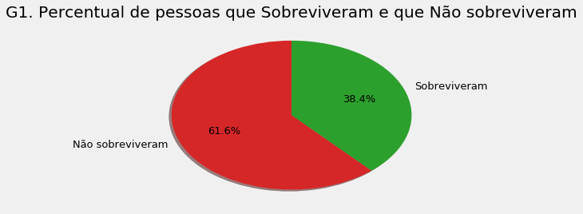

```python
df['Sobreviveu'].value_counts().plot.pie(colors=('tab:red', 'tab:green'),
                                       title='G1. Percentual de pessoas que Sobreviveram e que Não sobreviveram',
                                       fontsize=13, shadow=True, startangle=90, autopct='%1.1f%%',
                                       labels=('Não sobreviveram','Sobreviveram'),
                                       figsize=(6,4)).set_ylabel('')
```

### 2 - CLASSE

Vamos analisar agora as informações relacionadas â Classe em que a pessoa estava. Saber se houve ou não alguma influência sobre a pessoa ter sobrevivido ou não

##### Quantidade de pessoas por classe

```python
df.pivot_table(index='Classe',  values='Nome', aggfunc='count')
```

| Classe | Nome |
| --- | --- |
| 1 | 216 |
| 2 | 184 |
| 3 | 491 |

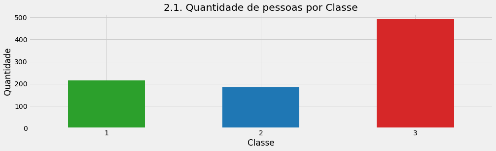

```python
df.pivot_table(index='Classe',  values='Nome', aggfunc='count').plot(kind='bar', legend=None, figsize=(15,4),\
                                                                     title="2.1. Quantidade de pessoas por Classe",
                                                                     color=vcolor2, rot=0).set_xlabel('Classe')
plt.ylabel('Quantidade')
```

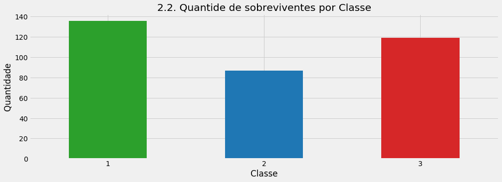

```python
df[df['Sobreviveu'] == 1].groupby('Classe').sum()['Sobreviveu'].plot(kind='bar',
                                                      title='2.2. Quantide de sobreviventes por Classe',
                                                      color=vcolor2, rot=0).set_xlabel('Classe')
plt.ylabel('Quantidade')
```

Obseve que apesar do número maior de pessoas ser da 3a classe (grafico 2.1) o número maior de sobreviventes foi da 1a classe.

```python
df_survived = df.groupby('Classe')[['Sobreviveu']].sum()
```

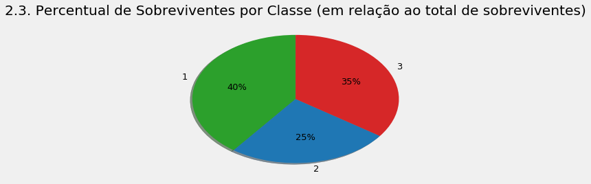

```python
df_survived.apply(lambda x: (x / x.sum(axis=0))*100)['Sobreviveu'].plot.pie(fontsize=13,
                             title='2.3. Percentual de Sobreviventes por Classe (em relação ao total de sobreviventes)',
                             startangle=90, autopct='%1.0f%%', shadow=True, colors=vcolor2,
                             figsize=(6,4)).set_ylabel('')
```

A classe que teve o menor percentual de sobreviventes foi a 2a classe (25% do total de sobreviventes).

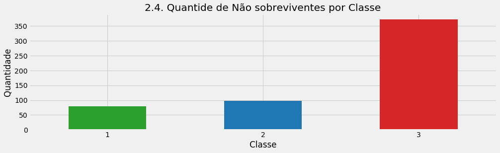

```python
df[df['Não sobreviveu'] == 1].groupby('Classe').sum()['Não sobreviveu'].plot(kind='bar',
                                                      title='2.4. Quantide de Não sobreviventes por Classe',
                                                      color=vcolor2, rot=0, figsize=(15,4)).set_xlabel('Classe')
plt.ylabel('Quantidade')
```

```python
df_nsurvived = df.groupby('Classe')[['Não sobreviveu']].sum()
```

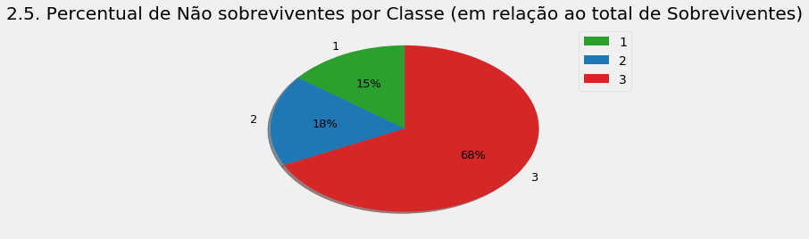

```python
df_nsurvived.apply(lambda x: (x / x.sum(axis=0))*100)['Não sobreviveu'].plot.pie(fontsize=13,
                             title='2.5. Percentual de Não sobreviventes por Classe (em relação ao total de Sobreviventes)',
                             startangle=90, autopct='%1.0f%%', shadow=True, colors=vcolor2, legend=True,
                             figsize=(6,4), labels=('1','2','3')).legend(bbox_to_anchor=(1.0, 1.0))
plt.ylabel('')
```

De todas as pessoas que Não sobreviveram, 68% eram da 3a classe. Enquanto que na primeira e segunda foram 15% e 18% respectivamente.

#### Segue um gráfico com a proporção de de pessoas que Sobreviveram e que Não sobreviveram por Classe

```python
df_prop = df.pivot_table(index='Classe',  values=('Sobreviveu','Não sobreviveu'), aggfunc=np.sum)
```

```python
df_prop['Proporção de Sobreviventes'] = df_prop['Sobreviveu'] / df['PassengerId'].count()
df_prop['Proporção de Não Sobreviventes'] = df_prop['Não sobreviveu'] / df['PassengerId'].count()
```

```python
df_prop.drop('Sobreviveu', axis=1, inplace=True)
df_prop.drop('Não sobreviveu', axis=1, inplace=True)
```

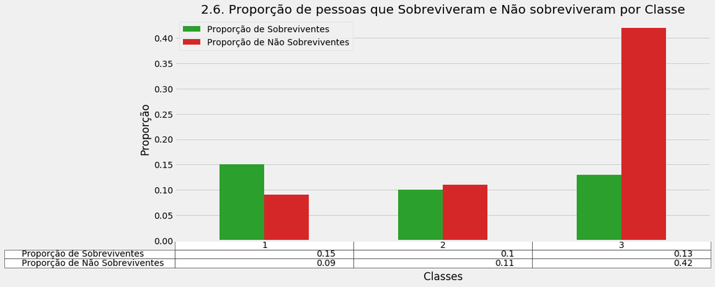

```python
df_prop.round(2).plot(kind='bar', rot=0, color=('tab:green','tab:red'),
              title='2.6. Proporção de pessoas que Sobreviveram e Não sobreviveram por Classe',
              table=True)
plt.ylabel('Proporção')
plt.xlabel('Classes', labelpad=50)
plt.xticks([])
plt.axes().set_position([0.15, 0.30, 0.80, 1.0]) # set_position([left, bottom, width, height])
```

A proproção acima é em relação ao total de pessoas. Aqui podemos ver a grande diferença entre a primeira e a segunda classe em relação a terceira classe

```python
df_prop2 = df.pivot_table(index='Classe',  values=('Sobreviveu','Não sobreviveu'), aggfunc=np.sum)
```

```python
df_prop2['Percentual de Sobreviventes'] = df_prop2['Sobreviveu'] / (df_prop2['Sobreviveu'] + df_prop2['Não sobreviveu'])
df_prop2['Percentual de Não Sobreviventes'] = df_prop2['Não sobreviveu'] / (df_prop2['Sobreviveu'] + df_prop2['Não sobreviveu'])
```

```python
df_prop2
```

| Classe | Não sobreviveu | Sobreviveu | Percentual de Sobreviventes | Percentual de Não Sobreviventes |
| --- | --- | --- | --- | --- |
| 1 | 80 | 136 | 0.63 | 0.37 |
| 2 | 97 | 87 | 0.47 | 0.53 |
| 3 | 372 | 119 | 0.24 | 0.76 |

```python
df_prop2.drop('Sobreviveu', axis=1, inplace=True)
df_prop2.drop('Não sobreviveu', axis=1, inplace=True)
```

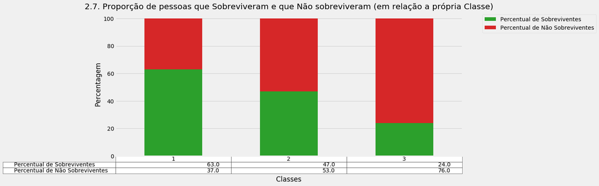

```python
df_prop2.applymap(lambda x: x * 100).round(0).plot(kind='bar', color=('tab:green', 'tab:red'), #'rbrgkymc',
              title='2.7. Proporção de pessoas que Sobreviveram e que Não sobreviveram (em relação a própria Classe)',
              grid=True, table=True, rot=0, stacked=True).legend(bbox_to_anchor=(1.05, 1.0))
plt.ylabel('Percentagem')
plt.xlabel('Classes', labelpad=50)
plt.xticks([])
plt.axes().set_position([0.15, 0.30, 0.80, 1.0]) # set_position([left, bottom, width, height])
```

O gráfico acima mostra o percentual de Sobreviventes e de Não sobreviventes em relação a própria classe e não em relação ao total de passageiros.

### 3 - SEXO

Realizando exploração nos dados com relação ao Sexo

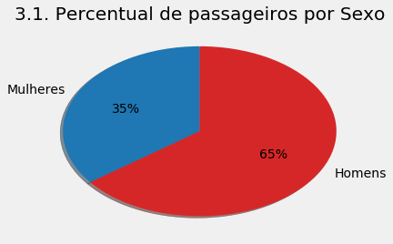

```python
df.groupby('Sexo').count()['PassengerId'].plot.pie(title='3.1. Percentual de passageiros por Sexo',
                                                  colors=vcolor, figsize=(6,4), labels=('Mulheres','Homens'),
                                                  startangle=90, autopct='%1.0f%%', shadow=True).set_ylabel('')
```

A maior parte das pessoas abordo do Titanic, eram homens (65%).

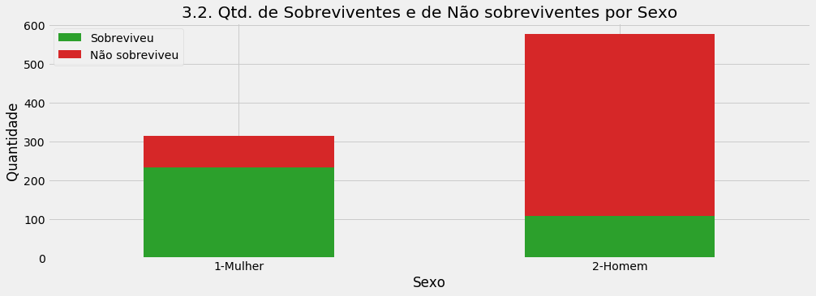

```python
df.pivot_table(index='Sexo',  values=('Sobreviveu','Não sobreviveu'), aggfunc=np.sum)[['Sobreviveu','Não sobreviveu']].plot(
    kind='bar', rot=0, label=('Feminino','Masculino'),
    color=('tab:green','tab:red'), stacked=True,
    title='3.2. Qtd. de Sobreviventes e de Não sobreviventes por Sexo').set_xlabel('Sexo')
plt.ylabel('Quantidade')
```

Podemos observar a disparidade entre as informações das Mulheres e dos homens. Vejam a relaçao entre Sobreviente e Não sobrevientes.

```python
df.pivot_table('PassengerId', ["Sexo"], 'Classe', aggfunc='count')
```

| Classe Sexo | 1 | 2 | 3 |
| --- | --- | --- | --- |
| 1-Mulher | 94 | 76 | 144 |
| 2-Homem | 122 | 108 | 347 |

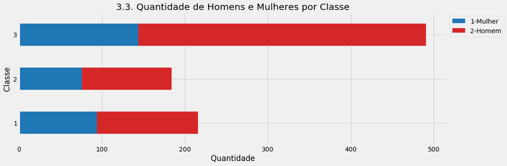

```python
df.pivot_table('PassengerId', ['Classe'], 'Sexo', aggfunc='count').sort_index().plot(kind='barh',
                                            color=('tab:blue','tab:red'), stacked=True,
                                            title='3.3. Quantidade de Homens e Mulheres por Classe').legend(bbox_to_anchor=(1.0, 1.0))
plt.xlabel('Quantidade')
```

No gráfico acima é possível identificar a distribuição de mulheres ou homens nas três classes. A classe com maior número de homens e mulheres é a terceira classe

```python
df.groupby(['Sexo','Classe']).sum()[['Sobreviveu','Não sobreviveu']]
```

| Sexo | Classe | Sobreviveu | Não sobreviveu |
| --- | --- | --- | --- |
| 1-Mulher | 1 | 91 | 3 |
|  | 2 | 70 | 6 |
|  | 3 | 72 | 72 |
| 2-Homem | 1 | 45 | 77 |
|  | 2 | 17 | 91 |
|  | 3 | 47 | 300 |

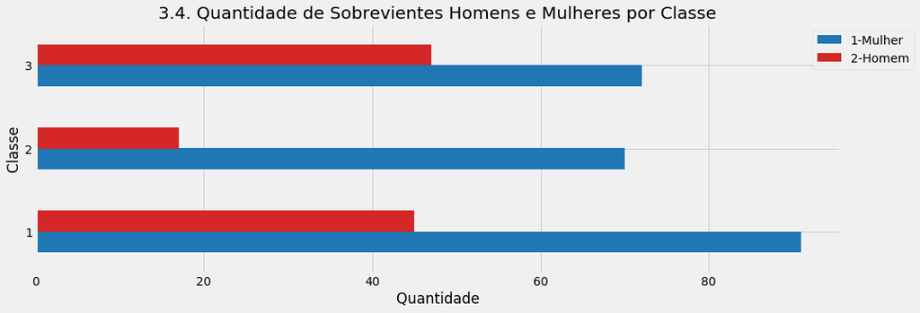

```python
df[df['Sobreviveu'] == 1].pivot_table('PassengerId', ['Classe'], 'Sexo', aggfunc='count').plot(kind='barh',
                                                                      color=('tab:blue','tab:red'),
                                                                      title='3.4. Quantidade de Sobrevientes Homens e Mulheres por Classe')\
                                                                      .legend(bbox_to_anchor=(1.1, 1.0))
plt.xlabel('Quantidade')
```

A classe com maior diferença entre a sobrevivência entre homens e mulhesres foi a 2a classe.

```python
df1 = df[df['Sobreviveu'] == 1].pivot_table('PassengerId', ['Sexo'], 'Classe', aggfunc='count')
```

```python
df2 = df.pivot_table('PassengerId', ['Sexo'], 'Classe', aggfunc='count')
```

```python
df2
```

| Classe Sexo | 1 | 2 | 3 |
| --- | --- | --- | --- |
| 1-Mulher | 94 | 76 | 144 |
| 2-Homem | 122 | 108 | 347 |

```python
df1.rename(index={'1-Mulher': '1.2. Mulheres Sobreviventes'}, inplace=True)
df1.rename(index={'2-Homem': '2.2. Homens Sobreviventes'}, inplace=True)
df2.rename(index={'1-Mulher': '1.1.  Mulheres TOTAL'}, inplace=True)
df2.rename(index={'2-Homem': '2.1. Homens TOTAL'}, inplace=True)
```

```python
df_res = pd.concat([df1, df2], axis=0)
```

```python
df_res.sort_index(ascending=True)
```

| Classe Sexo | 1 | 2 | 3 |
| --- | --- | --- | --- |
| 1.1. Mulheres TOTAL | 94 | 76 | 144 |
| 1.2. Mulheres Sobreviventes | 91 | 70 | 72 |
| 2.1. Homens TOTAL | 122 | 108 | 347 |
| 2.2. Homens Sobreviventes | 45 | 17 | 47 |

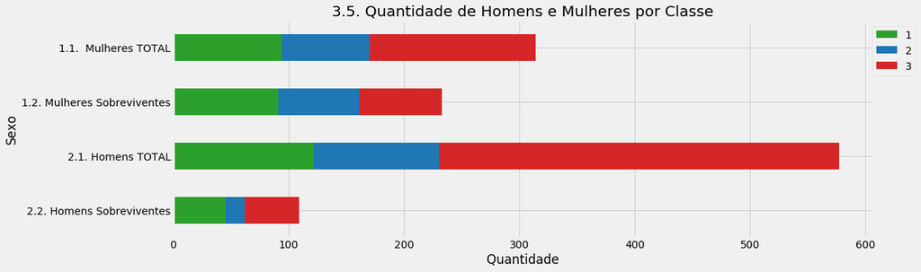

```python
df_res.sort_index(ascending=False).plot(kind='barh',
                                        color=('tab:green','tab:blue', 'tab:red'), stacked=True,
                                        title='3.5. Quantidade de Homens e Mulheres por Classe').legend(bbox_to_anchor=(1.07, 1.0))
plt.xlabel('Quantidade')
```

Atavés deste gráfico podemos fazer uma série de comparações:

Vamos agora criar uma visualização das informações acima para facilitar a comparação (distância) entre as informações

```python
df_res2 = df_res.transpose()
```

[output not shown]

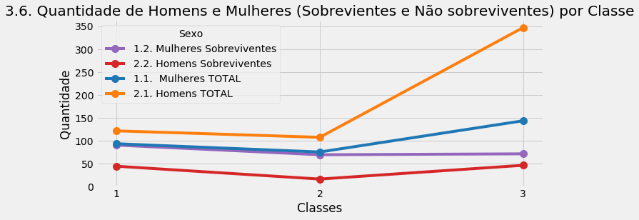

```python
df_res2.sort_index(ascending=True).plot(title='3.6. Quantidade de Homens e Mulheres (Sobrevientes e Não sobreviventes) por Classe',
                                        figsize=(10,4), marker='o', markersize=10,
                                        color=('tab:purple','tab:red','tab:blue','tab:orange'))
plt.xlabel('Classes')
plt.ylabel('Quantidade')
plt.xlim(0.9, 3.1)
plt.xticks([1,2,3])
```

O gráfico acima mostra de uma maneira simples a distância entre os sobreviventes e não sobrevientes. Com o foco no sexo feminino, podemos verificar a distância entre a linha azul (1.1. Mulheres TOTAL) e a linha roxa (1.2. Mulheres Sobreviventes). Compare a distância entre uma e outra de acordo com a classe (1, 2 e 3 - Eixo X). A quantidade de sobrevientes entre a 1a e 2a classe são praticamente iguais. Fica mais distante quando chegamos na 3a classe.

Agora façamos essa mesma análise para o sexo masculino. Note a distância entre a linha Laranja (2.1. Homens TOTAL), e a linha vermelha (2.2. Homens Sobreviventes). Note que há uma distâcia bastante grande, principalmente conforme vamos aumentando o número da classe.

- As mulheres da 1a e 2a classe tiveram maiores chances de sobreviverem em relação as mulheres da 3 classe?

```python
df.pivot_table(index=('Sexo','Classe'),  values=('Sobreviveu','Não sobreviveu'), aggfunc=np.sum)[['Sobreviveu','Não sobreviveu']]
```

| Sexo | Classe | Sobreviveu | Não sobreviveu |
| --- | --- | --- | --- |
| 1-Mulher | 1 | 91 | 3 |
|  | 2 | 70 | 6 |
|  | 3 | 72 | 72 |
| 2-Homem | 1 | 45 | 77 |
|  | 2 | 17 | 91 |
|  | 3 | 47 | 300 |

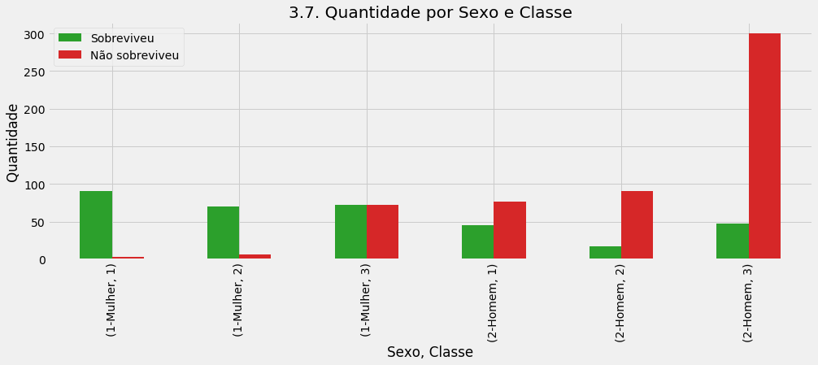

```python
df.pivot_table(index=('Sexo','Classe'),  values=('Sobreviveu','Não sobreviveu'), aggfunc=np.sum)[['Sobreviveu','Não sobreviveu']].plot(kind='bar',
color=('tab:green','tab:red'),
title='3.7. Quantidade por Sexo e Classe').set_xlabel('Sexo, Classe')
plt.ylabel('Quantidade')
```

Quase 100% das muheres da 1a e 2a classe se salvaram, enquanto que as mulheres da terceira classe a proporção foi de meio a meio, ou seja, 50% se salvou e 50% não. Então podemos concluir que sim, as mulheres da 1a e segunda classe foram favorecidas em relação as da 3a classe.

Podemos notar algo interssante, a quantidade de SOBREVIVENTES é a mais alta na barra da esquerda (mulheres da primeira classe) e vem caindo. Sobe um pouco quando chegamos nos nos homens da terceira classe. E a quantidade de NÃO SOBREVIENTES é ao contrário, a quantidade menor identificada é justamente na primeira barra e vem subindo cada vez mais, e atinte o pico máximo com os homens da terceira classe. Forma-se uma espécie de X.

Proporção em relação à própria classe:

```python
df.pivot_table(index=('Sexo','Classe'),  values=('Sobreviveu','Não sobreviveu'), aggfunc=np.sum)
```

| Sexo | Classe | Não sobreviveu | Sobreviveu |
| --- | --- | --- | --- |
| 1-Mulher | 1 | 3 | 91 |
|  | 2 | 6 | 70 |
|  | 3 | 72 | 72 |
| 2-Homem | 1 | 77 | 45 |
|  | 2 | 91 | 17 |
|  | 3 | 300 | 47 |

```python
df_woman = df[df['Sexo'] == '1-Mulher'].groupby('Classe').agg({'Sobreviveu': ['sum'], 'Não sobreviveu': ['sum']})
#df_woman = df[df['Sex'] == 'female'].groupby('Pclass')['Survived', 'Nsurvived'].sum()
```

```python
df_woman['Percentual de sobreviventes'] = ((df_woman['Sobreviveu'] / (df_woman['Sobreviveu'] + df_woman['Não sobreviveu'])) * 100)
```

```python
df_woman['Percentual de Não sobreviventes'] = 100 - df_woman['Percentual de sobreviventes']
```

```python
df_woman.drop('Sobreviveu', axis=1, inplace=True)
df_woman.drop('Não sobreviveu', axis=1, inplace=True)
```

```python
df_woman
```

| Classe | Percentual de sobreviventes | Percentual de Não sobreviventes |
| --- | --- | --- |
| 1 | 96.81 | 3.19 |
| 2 | 92.11 | 7.89 |
| 3 | 50.00 | 50.00 |

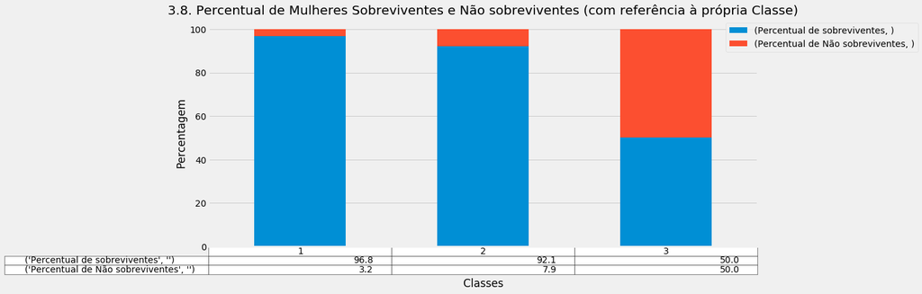

```python
df_woman.round(1).plot(kind='bar',rot=0,
              title='3.8. Percentual de Mulheres Sobreviventes e Não sobreviventes (com referência à própria Classe)',
              stacked=True, table=True).legend(bbox_to_anchor=(1.3, 1.0))
plt.ylabel('Percentagem')
plt.xlabel('Classes', labelpad=50)
plt.xticks([])
plt.axes().set_position([0.15, 0.30, 0.80, 1.0]) # set_position([left, bottom, width, height])
```

Note acima que aproximadamente 97% das mulheres da 1a classe sobrevieram, e da 2a classe 92% sobreviveram. enquanto que das mulheres da 3a classe somente 50% sobreviveram.

### 4 - IDADE

Como saber que pode ter sido um fator relevante?

Conforme já identificado anteriormente, existe uma parcela das pessoas que estavam com a idade sem preenchimento. Vamos verificar:

```python
print('Passageiros SEM idade preenchida:',df['Idade'].isnull().sum())
print('Passageiros COM idade preenchida:',(~df['Idade'].isnull()).sum())
```

```
Passageiros SEM idade preenchida: 177
Passageiros COM idade preenchida: 714
```

Das 891 pessoas, 177 (aproximadamente 20%) estão com idade sem preenchimento.

É possível utilizar técnicas inclusive com a utilização de Machine Learning para predizer quais valores poderíamos utilizar para preencher a idade dos registros que estão sem preenchimento. No entanto para esta análise, iremos utilizar a abordagem mais simples que é desconsiderar os registros nulos.

Agora iremos viualizar a distribuição da idade:

**Histograma por Idade**

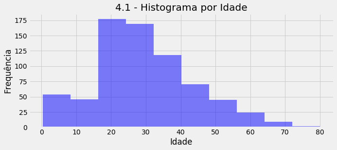

```python
plt.figure();
df.hist(column='Idade', color=('blue'), alpha=0.5, bins=10, figsize=(10,4))
plt.title('4.1 - Histograma por Idade')
plt.xlabel('Idade')
plt.ylabel('Frequência')
```

A maioria dos passageiros tinham aproximadamente 18 e 32 anos.

Em relação à idade, será que as crianças tiveram alguma preferência?

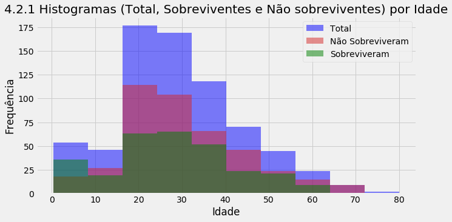

```python
df_histage = pd.DataFrame({'Total': df['Idade'],
                           'Não Sobreviveram': df[df['Não sobreviveu'] == 1]['Idade'],
                           'Sobreviveram': df[df['Sobreviveu'] == 1]['Idade']},

                          columns=['Total','Não Sobreviveram', 'Sobreviveram'])

plt.figure();

df_histage.plot.hist(bins=10, alpha=0.5, figsize=(10,5), color=('blue','tab:red','green'),
                     title='4.2.1 Histogramas (Total, Sobreviventes e Não sobreviventes) por Idade')
plt.xlabel('Idade')
plt.ylabel('Frequência')
plt.show()
```

Analisando o gráfico acima, podemos ver que a faixa onde encontram-se as crianças (de 0 a 10) tem um alto indice de sobrevivencia.

Vamos desenvolver o gráfico abaixo onde a visualização das idades ficarão ainda mais evidêntes:

[output not shown]

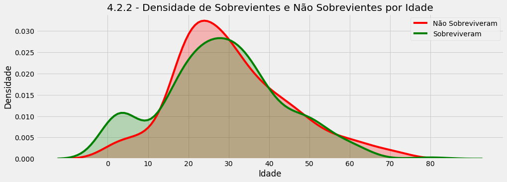

```python
ax = sns.kdeplot(df_histage['Não Sobreviveram'], shade=True, color="r")
ax = sns.kdeplot(df_histage['Sobreviveram'], shade=True, color="g")
plt.title('4.2.2 - Densidade de Sobrevientes e Não Sobrevientes por Idade')
plt.xlabel('Idade')
plt.ylabel('Densidade')
plt.xticks((0, 10, 20, 30, 40, 50, 60, 70, 80))
```

Observe que em relação a quantiade de Sobreviventes e de Não sobreviventes, a faixa de idade entre 0 e aproximadamente 10 anos foi de todas a faixa que mais houveram sobrevientes.

Vamos analisar a média de sobrevivência das crianças e depois compararmos com a média de sobreivência dos adultos.

Iremos considerar crianças com idade menor que 12 anos.

```python
df_age = df.copy()
```

```python
# Excluir registros sem idade preenchida
df_age.drop(df_age[df_age['Idade'].isnull() == True].index ,inplace=True)
```

```python
df_age['Crianca_Adulto'] = 0
```

```python
df_age.loc[df_age[df_age['Idade'] < 12].index, 'Crianca_Adulto'] = 'Crianças'
```

```python
df_age.loc[df_age[df_age['Idade'] >= 12].index, 'Crianca_Adulto'] = 'Não crianças'
```

```python
df_age.groupby('Crianca_Adulto')[['Sobreviveu']].mean()
```

| Crianca_Adulto | Sobreviveu |
| --- | --- |
| Crianças | 0.57 |
| Não crianças | 0.39 |

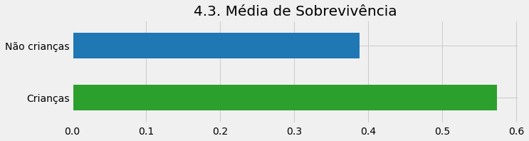

```python
df_age.groupby('Crianca_Adulto')['Sobreviveu'].mean().plot.barh(title='4.3. Média de Sobrevivência', figsize=(10,2.5),
                                                                color=('tab:green','tab:blue')).set_ylabel('')
plt.xlabel('')
```

Vamos analisar as quantidades:

```python
df_age_grp = df_age.groupby('Crianca_Adulto')['Sobreviveu','Não sobreviveu'].sum()
```

```python
df_age_grp
```

| Crianca_Adulto | Sobreviveu | Não sobreviveu |
| --- | --- | --- |
| Crianças | 39 | 29 |
| Não crianças | 251 | 395 |

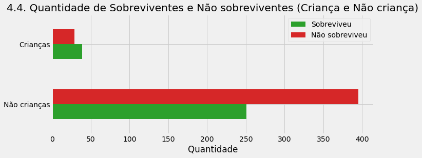

```python
df_age.groupby(['Crianca_Adulto'])['Sobreviveu','Não sobreviveu'].sum().sort_values(by='Sobreviveu', ascending=False) \
      .plot(kind='barh', figsize=(10,4), title='4.4. Quantidade de Sobreviventes e Não sobreviventes (Criança e Não criança)',
            color=('tab:green','tab:red')).set_ylabel('')

plt.xlabel('Quantidade')
```

Podemos ver acima que a quantidade de **Crianças** Soberviventes foram maiores que a quantidade de Não sobreviventes, enquanto que a quantidade de **Não crianças** sobreviventes, foi muito inferior à quantidade de Não Sobreviventes.

Em resumo, as "Crianças" sobreviveram mais do que morreram. Enquanto que as pessoas "Não crianças", morreram muito mais do que sobreviveram.

Quantidade de crianças por Classe

```python
df_criancas = df[(df['Idade'] <= 11) & (df['Sobreviveu'] == 1)].groupby('Classe').count()[['Sobreviveu']]
```

```python
df_criancas_tmp = df[(df['Idade'] <= 11) & (df['Sobreviveu'] == 0)].groupby('Classe').count()[['Sobreviveu']]
```

```python
result = pd.concat([df_criancas, df_criancas_tmp], axis=1)
```

```python
df_criancas_tmp2 = df[(df['Idade'] <= 11)].groupby('Classe').count()[['Sobreviveu']]
```

```python
result = pd.concat([result, df_criancas_tmp2], axis=1)
```

```python
result.columns.values[1] = 'Não sobreviveu'
```

```python
result.columns.values[2] = 'Total'
```

```python
result.fillna(0)
```

| Classe | Sobreviveu | Não sobreviveu | Total |
| --- | --- | --- | --- |
| 1 | 3 | 1.00 | 4 |
| 2 | 17 | 0.00 | 17 |
| 3 | 19 | 28.00 | 47 |

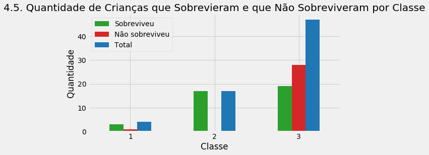

```python
result.fillna(0).plot(kind='bar', rot=0, figsize=(8,4),
                    color=('tab:green','tab:red','tab:blue'),
                     title='4.5. Quantidade de Crianças que Sobrevieram e que Não Sobreviveram por Classe')
plt.ylabel('Quantidade')
```

Novamente podemos observar que as primeiras classes tiveram um alto número de sobreviventes. Na primeira classe morreu somente uma e na segunda classe não morreu nenhuma criança, enquanto da terceira classe, das 47 crianças somente 19 sobrevieram.

Vamos criar uma visualização para identificar o percentual de Crianças sobreviventes e de Não sobrevivêntes por classe

```python
result_perc = result.copy()
result_perc['% Não sobreviveu'] = (result_perc['Não sobreviveu'] / result_perc['Total']) * 100
result_perc['% Sobreviveu'] = (result_perc['Sobreviveu'] / result_perc['Total']) * 100
```

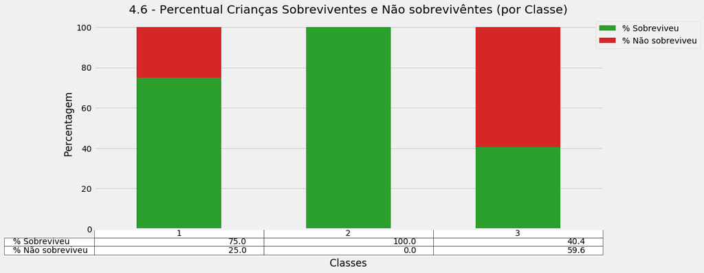

```python
result_perc[['% Sobreviveu','% Não sobreviveu']].fillna(0).round(1).plot(kind='bar', title='4.6 - Percentual Crianças Sobreviventes e Não sobrevivêntes (por Classe)',
                                                           rot=0, stacked=True, table=True,
                                                           color=('tab:green', 'tab:red')).legend(bbox_to_anchor=(1.2, 1.0))
plt.ylabel('Percentagem')
plt.xlabel('Classes', labelpad=50)
plt.xticks([])
plt.axes().set_position([0.15, 0.30, 0.80, 1.0]) # set_position([left, bottom, width, height])
```

O gráfico acima mostra a diferença que houve entre o percentua de crianças que sobreviveram e que não sobrevieram entre a primeira e segunda classe e a terceira classe.

60% das crianças da terceira classe morreram. Enquanto que na primeira classe morreram somente 25% e na segunda classe, das 17 criaças a bordo, nenhuma morreu.

### CONCLUSÃO:

Nossa análise exploratória teve como objetivo identificar atributos de alguns conjunto de pessoas para saber se tiveram maior chance de sobrevivência que outras.

Sabe-se que o navio possuia um número de botes muito inferior ao número necessário para salvar a quantidade de pessoas abordo. Mesmo assim, era um número acima do exigido pelas legislações marítimas na época. Sendo assim, houve alguma priorização para a utilização dos botes?

Identificamos que fatores como a Classe, Sexo e Idade realmente influenciaram para o aumento ou diminuição das chances de sobrevivência.

As mulheres foram as que tiveram maiores chances de sobrevivência. Principalmente as da primeira e segunda classe. Os gráficos 3.5, 3.6 e 3.7 mostram uma visão bem clara da diferença. Em resumo as maiores chances de sobrevivência foram para as mulheres da primeira e segunda classe. E as menores chances de sobrevivência foram para os homens da terceira classe.  
Realizando pesquisas foi encontrado um relato que o segundo oficial Lightoller se dirigiu ao capitão e sugeriu que a evacuação fosse iniciada com as mulheres e crianças. O capitão Smith concordou. Isso com certeza fez com que os indices de sobrevivência aumentassem e bastante, tanto para mulheres quanto para crianças.  
Obs.: A preferência do embarque para mulheres e crianças ocorrida no Titanic é considerada uma exceção, ou seja, geralmente isso não ocorre em outros naufrágios. Muitos homens, em sua maioria da primeira classe, se recusaram a entrar nos botes. Tiveram que ser persuadidos.

Em pesquisas realizadas também foi informado que muito poucas pessoas da terceira classe tinham conseguido chegar ao convés superior, com a maioria se perdendo nos labirintos de corredores ou ficando presos atrás de grades que segregavam as acomodações da terceira classe daquelas da primeira e segunda. Aparentemente em pelo menos em alguns lugares, a tripulação do Titanic ativamente impediu que os passageiros da terceira classe escapassem, com barreiras trancadas e vigiadas por tripulantes a fim de impedir que as pessoas corressem para os botes.  
Este estudo pode ser continuado com a análise de outras variáveis, explorar e encontrar novos insights utilizando as informações desta base para gerar novas variáveis, como por exmemplo saber se é possível identificar os tripulantes. Será que quem não tem informação de Tarifa (Fare) preenchida pode ser um tripulante? Seria possível indificá-los e encontrar sua taxa de sobrevivência e compará-la e ver se essa taxa foi maior que a taxa de sobrevivência dos passageiros? A própria idade como já comentado poderia ser explorada através de técnicas preditivas para identificarmos melhor como esta informação impactou na taxa de sobrevivência.  
*IMPORTANTE: É importante ressaltar que as conclusões identificadas não são definitivas, pois não estamos usando técnicas estatisticas para a realização deste estudo.*

### Fontes:

- RMS Titanic  
  https://pt.wikipedia.org/wiki/RMS_Titanic
- Kaggle  
  https://www.kaggle.com/c/titanic
- Python Data Analysis Library  
  https://pandas.pydata.org/pandas-docs/stable/visualization.html
- Seaborn: statistical data visualization  
  http://seaborn.pydata.org/
- Stackoverflow  
  https://stackoverflow.com/
- Paulo Vasconcellos - O que o Naufrágio do Titanic nos ensina até hoje  
  https://paulovasconcellos.com.br/o-que-o-naufr%C3%A1gio-do-titanic-nos-ensina-at%C3%A9-hoje-data-science-project-2fea8ff1c9b5
- ECD - Estatuto da Criança e do Adolescente  
  http://www.planalto.gov.br/ccivil_03/leis/L8069.htm
- Mundo Estranho  
  https://mundoestranho.abril.com.br/ambiente/em-naufragios-criancas-e-mulheres-tem-mesmo-prioridade/